# Week 5: Cluster Analysis, Pt 2

Xuan Pham

November 19, 2018

# Getting Started

You will need the following packages to follow along with this discussion: **cluster**, **clusterSim**, **klaR**, and **clustMixType**.

# Hierarchical Cluster Analysis

In Week 4, we discussed cluster analysis using the partitioning approach. Two algorithms were discussed: k-means and k-medoids. Both algorithms required data miners to choose the number of clusters, or k, to partition similar observations into groups.

We are turning our attention to a different approach of doing cluster analysis. Hierarchical cluster analysis groups similar observations together using a tree structure. There are two types of hierarchical clusters:

1. Aglomerative Nesting (AGNES): A bottom up approach. Each observation is initially considered its own cluster (leaf). Similar observations are grouped together into a bigger cluster (node). The process continue until all observations are grouped into one big cluster (root).
2. Divisive Analysis (DIANA): A top down approach. All observations initially belong to one big cluster (root). The most heterogenous cluster is divided into two clusters (nodes). The process iterates until all observations are their own clusters (leaves).

Here’s a good visualization of AGNES and DIANA:

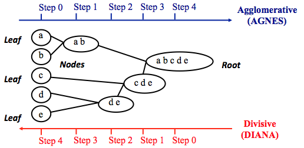

Two questions must be addressed with hierarchical clustering methods:

1. How do you measure dissimilarity between two observations? Fortunately, we already covered this last week. You can use either Euclidean or Manhattan distance.
2. How do you measure dissimilarity between two clusters? This is a tough question. These are the possible answers:

**Complete Linkage**: Computes all pairwise dissimilarities between the elements in cluster 1 and the elements in cluster 2. The largest value of these dissimilarities is used as the distance between the two clusters. This produces more compact clusters.

**Single Linkage**: Similar to complete linkage except the smallest value of the calculated dissimilarities is used as the distance between two clusters. This produces less compact clusters.

**Average Linkage**: The average of the calculated dissimilarities is used as the distance between two clusters.

**Centroid Linkage**: Uses the dissimilarity between the centroids of the two clusters.

**Ward’s Method**: Merges two clusters with the minimum between-cluster distance at each iteration.

Let’s deploy hierarchical clustering methods on the Cereals dataset!

## Preprocessing the Data

```r
library(tidyverse)
cereals <- read.csv("~/Dropbox/Fall_2018/BIA_6301/Week_4/Cereals.csv")

cereals$mfr <- recode_factor(cereals$mfr, 'A' = "American_Home_Food_Products", 'G' = "General_Mills", 'K' = "Kelloggs", 'N' = "Nabisco", 'P' = "Post", 'Q' = "Quaker_Oats", 'R' = "Ralston_Purina")
cereals$type <- recode_factor(cereals$type, 'C' = "Cold", 'H' = "Hot")
cereals$vitamins <- recode_factor(cereals$vitamins, '0' = "0", '25' = "25", '100' = "100")
cereals$shelf <- recode_factor(cereals$shelf, '1' = "Lowest", '2' = "Middle", '3' = "Highest")

cereals<-cereals[-c(5,21,58),] #remove rows with missing records
row.names(cereals) <- cereals$name #this ensures that we can trace back the cereal name in each row once we remove the name column

cereals_num <- cereals[,-c(1:3,12:13)] #remove categorical variables: name, mfr, type, vitamins, shelf

cereals_num_z<-scale(cereals_num) #scale the numeric variables
summary(cereals_num_z)
```

```
##     calories          protein              fat              sodium
##  Min.   :-2.8738   Min.   :-1.40687   Min.   :-0.9932   Min.   :-1.9616
##  1st Qu.:-0.3541   1st Qu.:-0.47733   1st Qu.:-0.9932   1st Qu.:-0.3306
##  Median : 0.1498   Median :-0.01256   Median : 0.0000   Median : 0.2131
##  Mean   : 0.0000   Mean   : 0.00000   Mean   : 0.0000   Mean   : 0.0000
##  3rd Qu.: 0.1498   3rd Qu.: 0.45221   3rd Qu.: 0.0000   3rd Qu.: 0.6661
##  Max.   : 2.6695   Max.   : 3.24083   Max.   : 3.9729   Max.   : 1.9045
##      fiber              carbo              sugars            potass
##  Min.   :-0.89778   Min.   :-2.50014   Min.   :-1.6306   Min.   :-1.1783
##  1st Qu.:-0.79462   1st Qu.:-0.70143   1st Qu.:-0.9424   1st Qu.:-0.8079
##  Median :-0.07249   Median :-0.05903   Median :-0.0248   Median :-0.1201
##  Mean   : 0.00000   Mean   : 0.00000   Mean   : 0.0000   Mean   : 0.0000
##  3rd Qu.: 0.34015   3rd Qu.: 0.58337   3rd Qu.: 0.8928   3rd Qu.: 0.3031
##  Max.   : 4.87925   Max.   : 2.12512   Max.   : 1.8104   Max.   : 3.2660
##      weight             cups             rating
##  Min.   :-3.4600   Min.   :-2.4251   Min.   :-1.7336
##  1st Qu.:-0.2008   1st Qu.:-0.6432   1st Qu.:-0.7071
##  Median :-0.2008   Median :-0.3038   Median :-0.1510
##  Mean   : 0.0000   Mean   : 0.0000   Mean   : 0.0000
##  3rd Qu.:-0.2008   3rd Qu.: 0.7568   3rd Qu.: 0.5807
##  Max.   : 3.0583   Max.   : 2.8780   Max.   : 3.6578
```

## Using hclust() in base R

First, we need to compute the Euclidean distance between observations. This gives us the dissimilarity matrix.

```r
library(cluster)
dis.matrix <- dist(cereals_num_z, method="euclidean")
```

Now we can do hierarchical clustering.

```r
set.seed(123)
complete.link <- hclust(dis.matrix, method = "complete")
single.link <- hclust(dis.matrix, method = "single")
average.link <- hclust(dis.matrix, method = "average")
centroid.link <- hclust(dis.matrix, method = "centroid")
ward <- hclust(dis.matrix, method="ward.D")
```

Let’s visualize the outputs. Each visualization is called a dendrogram.

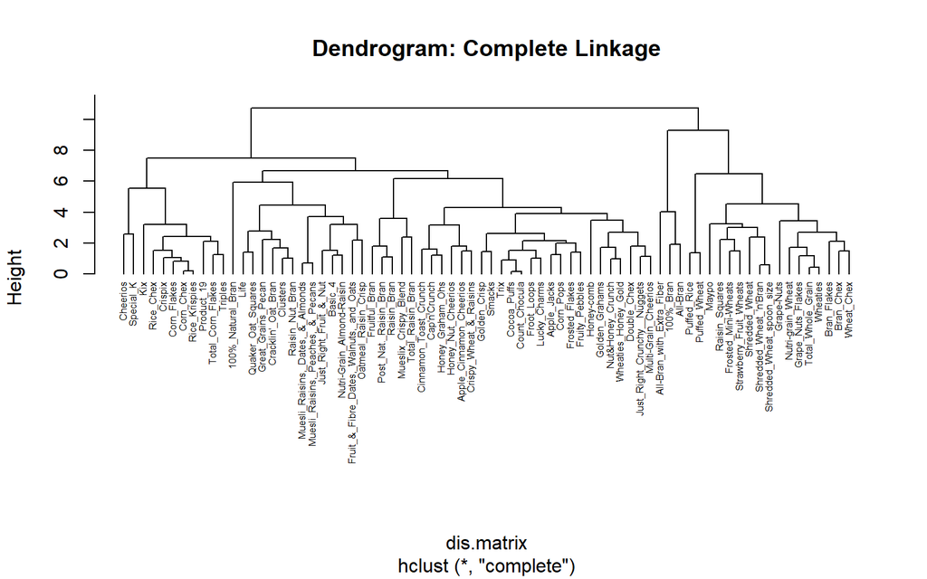

```r
plot(complete.link, cex = 0.5, main = "Dendrogram: Complete Linkage", hang=-1)
```

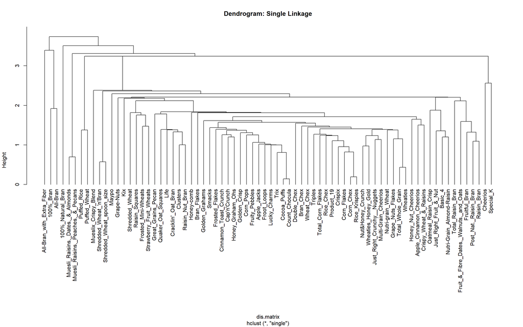

```r
plot(single.link, main = "Dendrogram: Single Linkage", hang=-1)
```

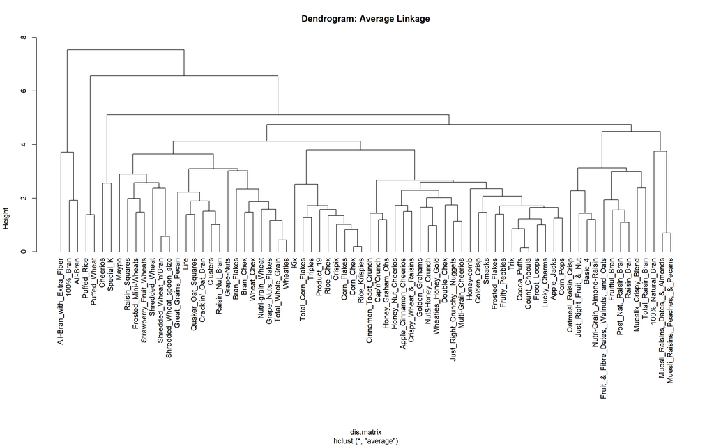

```r
plot(average.link, main = "Dendrogram: Average Linkage", hang=-1)
```

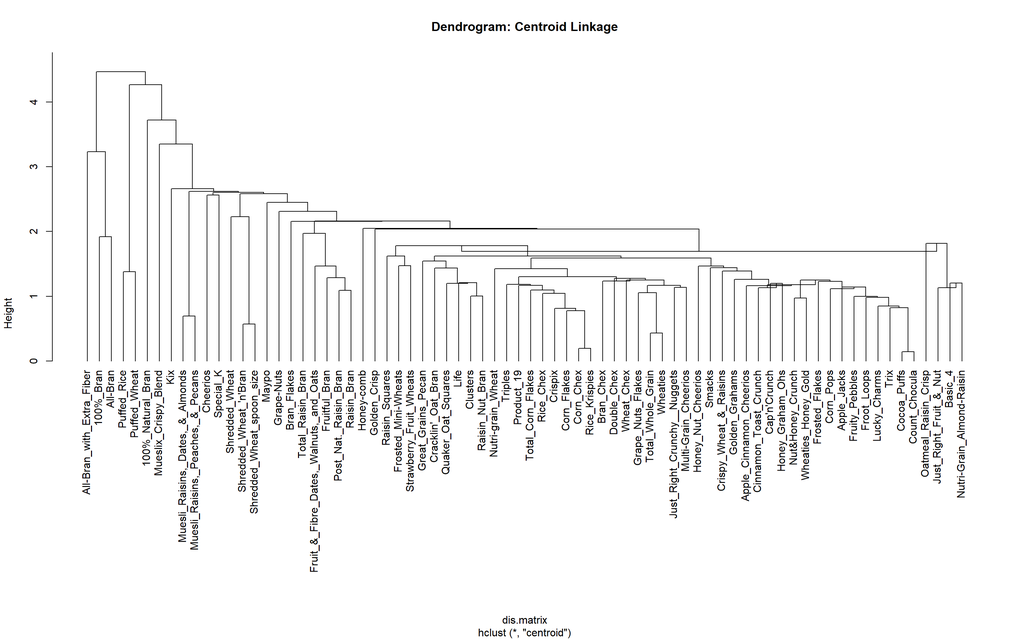

```r
plot(centroid.link, main = "Dendrogram: Centroid Linkage", hang=-1)
```

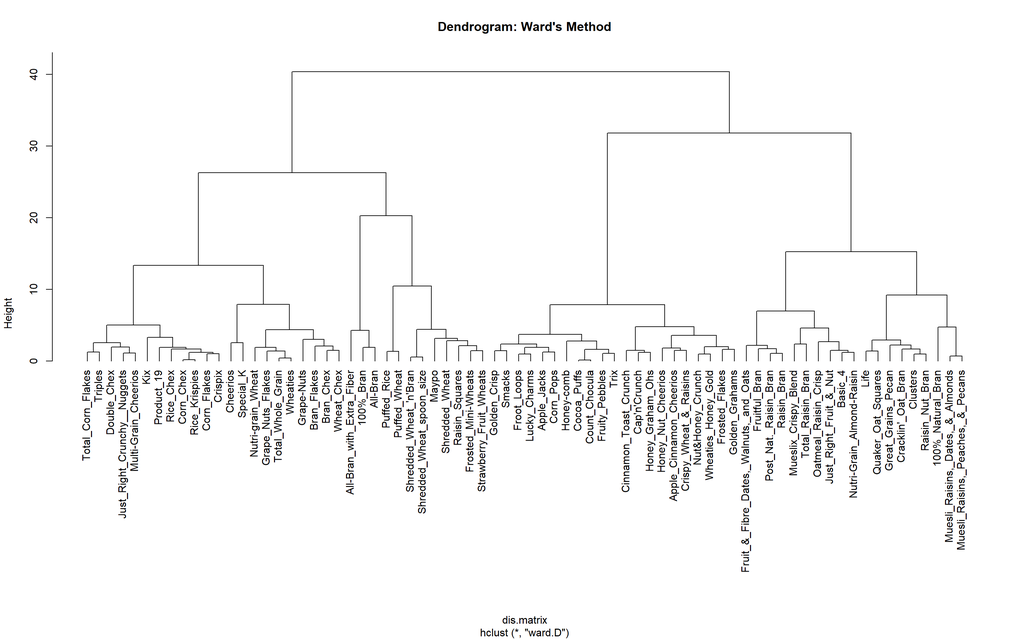

```r
plot(ward, main = "Dendrogram: Ward's Method", hang=-1)
```

From the available documentation for the hclust() function on CRAN, the authors described that hclust() uses an agglomerative nesting approach.

```r
#?hclust
```

### Cutting a Dendrogram

Is it three clusters? Or four clusters?

```r
set.seed(123)
clusters3 <- cutree(complete.link, k=3)
table(clusters3)
```

```
## clusters3
##  1  2  3
##  3 54 17
```

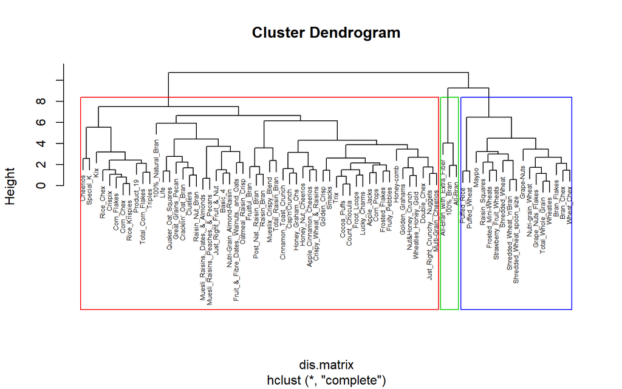

```r
plot(complete.link, cex = 0.5)
rect.hclust(complete.link, k = 3, border = 2:4)
```

```r
set.seed(123)
clusters4 <- cutree(complete.link, k=4)
table(clusters3)
```

```
## clusters3
##  1  2  3
##  3 54 17
```

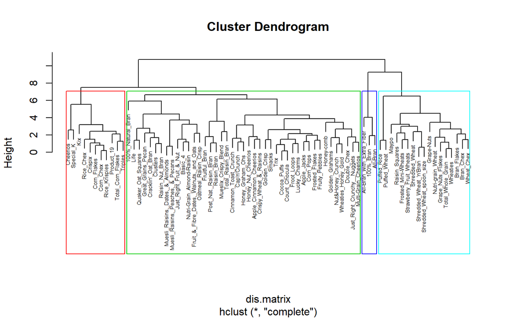

```r
plot(complete.link, cex = 0.5)
rect.hclust(complete.link, k = 4, border = 2:5)
```

### Choosing k

One way to choose the appropriate number of k is to look at the pseudo F-statistic. As a reminder from last week, we want a larger value, which indicates that we have cohesive and distinct clusters (large between cluster sum of squares and small within cluster sum of squares).

```r
library(clusterSim)
k3 <- index.G1(cereals_num, clusters3, centrotype = "centroids")
k4<-index.G1(cereals_num, clusters4, centrotype = "centroids")

k3
```

```
## [1] 15.92233
```

```r
k4
```

```
## [1] 17.33806
```

## Agglomerative Nesting (AGNES) & Divisive Analysis (DIANA) Approaches

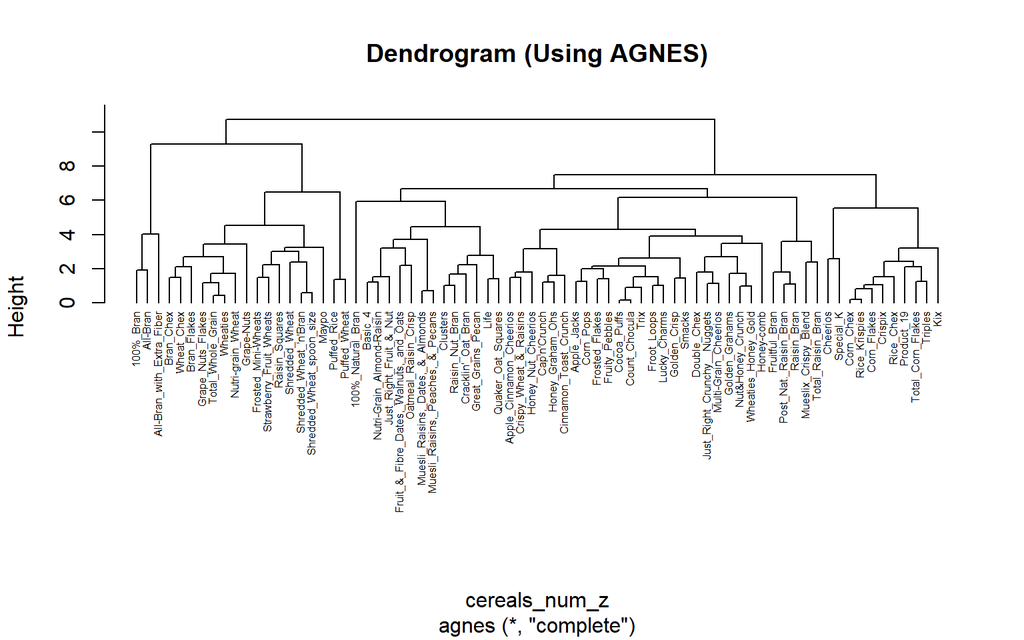

```r
library(cluster)
set.seed(123)
agnes.hclust <- agnes(cereals_num_z, method = "complete")

pltree(agnes.hclust, cex = 0.5, hang = -1,
       main = "Dendrogram (Using AGNES)")
```

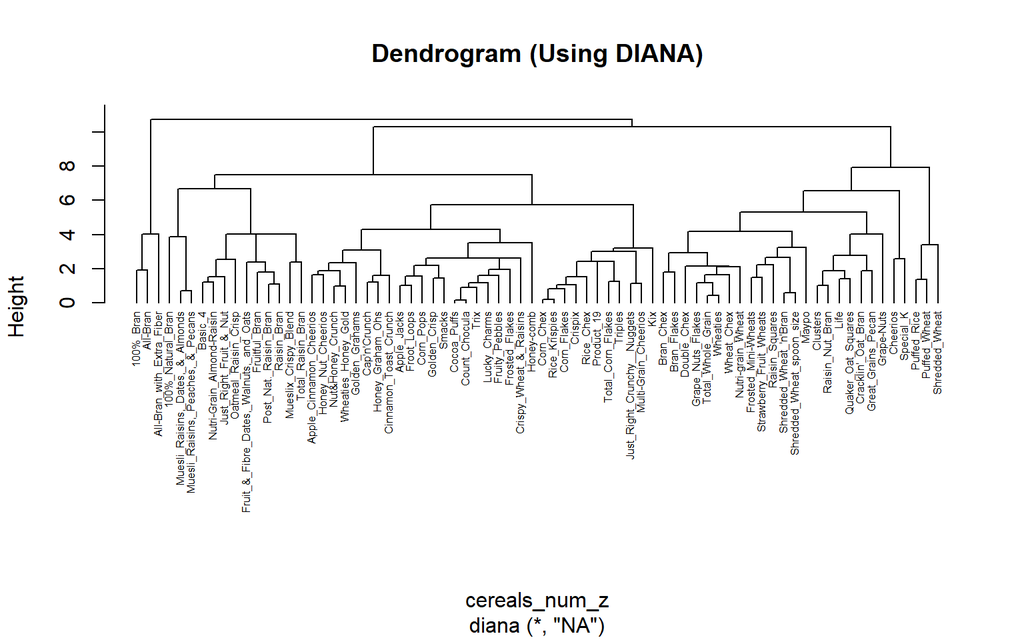

```r
library(cluster)
set.seed(123)
diana.hclust <- diana(cereals_num_z)

pltree(diana.hclust, cex = 0.5, hang = -1,
       main = "Dendrogram (Using DIANA)")
```

You will still have to figure out the appropriate number of k’s.

## Clustering Categorical Data

We removed four categorical variables earlier: mfr, type, vitamins, and shelf. K-means, k-medoids, and hierarchical clustering are not meant for categorical variables. So what are our options if we do want to cluster categorical variables?

### One Hot Coding

Henri Ralambondrainy (1995) proposed to recode each categorical variable into multiple dummy variables and then apply k-means algorithm. For example, the variable “type” has two categories: cold and hot. We would recode this variable into two dummy variables: type.cold and type.hot.

| Variable.Name | Yes | No |
| --- | --- | --- |
| type.cold | 1 | 0 |
| type.hot | 1 | 0 |

The cereal 100% Brand would be recoded as follows:

| type.cold | type.hot |
| --- | --- |
| 1 | 0 |

There are several drawbacks with this approach:

1. Recoding into dummy variables mean you are increasing the size of the data set, and, consequently, the computational costs. Furthermore, you will run into something called the **curse of dimensionality**, which is the other topic for this week.
2. The cluster centroid (i.e. mean) does not have a practical interpretation. You will get a mean value between 0 and 1, and this does not make sense in the context of categorical variables.
3. Euclidean distance does not make sense when you only have values of 0 and 1.

You should know that one hot coding and k-means are used by data miners despite its problems, so don’t be shocked when you do see it.

```r
cereals_cat <- cereals[,c(2:3,12:13)]
row.names(cereals_cat) <- cereals$name

library(dummies)
cereals_cat_dummies <- dummy.data.frame(cereals_cat, sep =".")

set.seed(123)
cereals_cat_dummies_kmeans <- kmeans(cereals_cat_dummies, centers=3)

cereals_cat_dummies_kmeans$centers #look at the centroids
```

```
##   mfr.American_Home_Food_Products mfr.General_Mills mfr.Kelloggs
## 1                      0.00000000         0.2812500            0
## 2                      0.00000000         0.0000000            1
## 3                      0.05263158         0.6842105            0
##   mfr.Nabisco   mfr.Post mfr.Quaker_Oats mfr.Ralston_Purina type.Cold
## 1  0.12500000 0.25000000       0.1250000            0.21875 1.0000000
## 2  0.00000000 0.00000000       0.0000000            0.00000 1.0000000
## 3  0.05263158 0.05263158       0.1578947            0.00000 0.9473684
##     type.Hot vitamins.0 vitamins.25 vitamins.100 shelf.Lowest shelf.Middle
## 1 0.00000000     0.1875   0.7187500    0.0937500    0.2812500    0.0000000
## 2 0.00000000     0.0000   0.8695652    0.1304348    0.1739130    0.3043478
## 3 0.05263158     0.0000   1.0000000    0.0000000    0.3157895    0.6842105
##   shelf.Highest
## 1     0.7187500
## 2     0.5217391
## 3     0.0000000
```

```r
cereals_cat$cluster_hotcode_kmeans <- cereals_cat_dummies_kmeans$cluster #assign cluster ID to each observation


#view the cereals in each cluster
subset(cereals_cat, cluster_hotcode_kmeans==1)
```

```
##                                                   mfr type vitamins
## 100%_Bran                                     Nabisco Cold       25
## 100%_Natural_Bran                         Quaker_Oats Cold        0
## Basic_4                                 General_Mills Cold       25
## Bran_Chex                              Ralston_Purina Cold       25
## Bran_Flakes                                      Post Cold       25
## Clusters                                General_Mills Cold       25
## Corn_Chex                              Ralston_Purina Cold       25
## Crispy_Wheat_&_Raisins                  General_Mills Cold       25
## Double_Chex                            Ralston_Purina Cold       25
## Fruit_&_Fibre_Dates,_Walnuts,_and_Oats           Post Cold       25
## Golden_Crisp                                     Post Cold       25
## Grape_Nuts_Flakes                                Post Cold       25
## Grape-Nuts                                       Post Cold       25
## Great_Grains_Pecan                               Post Cold       25
## Honey-comb                                       Post Cold       25
## Muesli_Raisins,_Dates,_&_Almonds       Ralston_Purina Cold       25
## Muesli_Raisins,_Peaches,_&_Pecans      Ralston_Purina Cold       25
## Oatmeal_Raisin_Crisp                    General_Mills Cold       25
## Post_Nat._Raisin_Bran                            Post Cold       25
## Puffed_Rice                               Quaker_Oats Cold        0
## Puffed_Wheat                              Quaker_Oats Cold        0
## Quaker_Oat_Squares                        Quaker_Oats Cold       25
## Raisin_Nut_Bran                         General_Mills Cold       25
## Rice_Chex                              Ralston_Purina Cold       25
## Shredded_Wheat                                Nabisco Cold        0
## Shredded_Wheat_'n'Bran                        Nabisco Cold        0
## Shredded_Wheat_spoon_size                     Nabisco Cold        0
## Total_Corn_Flakes                       General_Mills Cold      100
## Total_Raisin_Bran                       General_Mills Cold      100
## Total_Whole_Grain                       General_Mills Cold      100
## Triples                                 General_Mills Cold       25
## Wheat_Chex                             Ralston_Purina Cold       25
##                                          shelf cluster_hotcode_kmeans
## 100%_Bran                              Highest                      1
## 100%_Natural_Bran                      Highest                      1
## Basic_4                                Highest                      1
## Bran_Chex                               Lowest                      1
## Bran_Flakes                            Highest                      1
## Clusters                               Highest                      1
```

[output cut: 11 more lines]

```
## Oatmeal_Raisin_Crisp                   Highest                      1
## Post_Nat._Raisin_Bran                  Highest                      1
## Puffed_Rice                            Highest                      1
## Puffed_Wheat                           Highest                      1
## Quaker_Oat_Squares                     Highest                      1
## Raisin_Nut_Bran                        Highest                      1
## Rice_Chex                               Lowest                      1
## Shredded_Wheat                          Lowest                      1
## Shredded_Wheat_'n'Bran                  Lowest                      1
## Shredded_Wheat_spoon_size               Lowest                      1
## Total_Corn_Flakes                      Highest                      1
## Total_Raisin_Bran                      Highest                      1
## Total_Whole_Grain                      Highest                      1
## Triples                                Highest                      1
## Wheat_Chex                              Lowest                      1
```

```r
subset(cereals_cat, cluster_hotcode_kmeans==2)
```

```
##                                  mfr type vitamins   shelf
## All-Bran                    Kelloggs Cold       25 Highest
## All-Bran_with_Extra_Fiber   Kelloggs Cold       25 Highest
## Apple_Jacks                 Kelloggs Cold       25  Middle
## Corn_Flakes                 Kelloggs Cold       25  Lowest
## Corn_Pops                   Kelloggs Cold       25  Middle
## Cracklin'_Oat_Bran          Kelloggs Cold       25 Highest
## Crispix                     Kelloggs Cold       25 Highest
## Froot_Loops                 Kelloggs Cold       25  Middle
## Frosted_Flakes              Kelloggs Cold       25  Lowest
## Frosted_Mini-Wheats         Kelloggs Cold       25  Middle
## Fruitful_Bran               Kelloggs Cold       25 Highest
## Just_Right_Crunchy__Nuggets Kelloggs Cold      100 Highest
## Just_Right_Fruit_&_Nut      Kelloggs Cold      100 Highest
## Mueslix_Crispy_Blend        Kelloggs Cold       25 Highest
## Nut&Honey_Crunch            Kelloggs Cold       25  Middle
## Nutri-Grain_Almond-Raisin   Kelloggs Cold       25 Highest
## Nutri-grain_Wheat           Kelloggs Cold       25 Highest
## Product_19                  Kelloggs Cold      100 Highest
## Raisin_Bran                 Kelloggs Cold       25  Middle
## Raisin_Squares              Kelloggs Cold       25 Highest
## Rice_Krispies               Kelloggs Cold       25  Lowest
## Smacks                      Kelloggs Cold       25  Middle
## Special_K                   Kelloggs Cold       25  Lowest
##                             cluster_hotcode_kmeans
## All-Bran                                         2
## All-Bran_with_Extra_Fiber                        2
## Apple_Jacks                                      2
## Corn_Flakes                                      2
## Corn_Pops                                        2
## Cracklin'_Oat_Bran                               2
## Crispix                                          2
## Froot_Loops                                      2
## Frosted_Flakes                                   2
## Frosted_Mini-Wheats                              2
## Fruitful_Bran                                    2
## Just_Right_Crunchy__Nuggets                      2
## Just_Right_Fruit_&_Nut                           2
## Mueslix_Crispy_Blend                             2
## Nut&Honey_Crunch                                 2
## Nutri-Grain_Almond-Raisin                        2
## Nutri-grain_Wheat                                2
## Product_19                                       2
## Raisin_Bran                                      2
## Raisin_Squares                                   2
## Rice_Krispies                                    2
## Smacks                                           2
## Special_K                                        2
```

```r
subset(cereals_cat, cluster_hotcode_kmeans==3)
```

```
##                                                 mfr type vitamins  shelf
## Apple_Cinnamon_Cheerios               General_Mills Cold       25 Lowest
## Cap'n'Crunch                            Quaker_Oats Cold       25 Middle
## Cheerios                              General_Mills Cold       25 Lowest
## Cinnamon_Toast_Crunch                 General_Mills Cold       25 Middle
## Cocoa_Puffs                           General_Mills Cold       25 Middle
## Count_Chocula                         General_Mills Cold       25 Middle
## Fruity_Pebbles                                 Post Cold       25 Middle
## Golden_Grahams                        General_Mills Cold       25 Middle
## Honey_Graham_Ohs                        Quaker_Oats Cold       25 Middle
## Honey_Nut_Cheerios                    General_Mills Cold       25 Lowest
## Kix                                   General_Mills Cold       25 Middle
## Life                                    Quaker_Oats Cold       25 Middle
## Lucky_Charms                          General_Mills Cold       25 Middle
## Maypo                   American_Home_Food_Products  Hot       25 Middle
## Multi-Grain_Cheerios                  General_Mills Cold       25 Lowest
## Strawberry_Fruit_Wheats                     Nabisco Cold       25 Middle
## Trix                                  General_Mills Cold       25 Middle
## Wheaties                              General_Mills Cold       25 Lowest
## Wheaties_Honey_Gold                   General_Mills Cold       25 Lowest
##                         cluster_hotcode_kmeans
## Apple_Cinnamon_Cheerios                      3
## Cap'n'Crunch                                 3
## Cheerios                                     3
## Cinnamon_Toast_Crunch                        3
## Cocoa_Puffs                                  3
## Count_Chocula                                3
## Fruity_Pebbles                               3
## Golden_Grahams                               3
## Honey_Graham_Ohs                             3
## Honey_Nut_Cheerios                           3
## Kix                                          3
## Life                                         3
## Lucky_Charms                                 3
## Maypo                                        3
## Multi-Grain_Cheerios                         3
## Strawberry_Fruit_Wheats                      3
## Trix                                         3
## Wheaties                                     3
## Wheaties_Honey_Gold                          3
```

### Use Gower’s Similiarity Measure

Instead of using Euclidean distance, you can use Gower’s similarity measure and pair it with k-medoids. Gower’s measure requires that all variables must be scaled to a [0,1] range.

Gower’s measure is a “weighted average of the distances computed for each variable” (Shmueli et al. 2018, p. 366).

Here’s the technical calculations of Gower’s measure:

$s_{ij} = \frac{\sum{_{m=1}} w_{ijm}s_{ijm}}{\sum{_{m=1} w_{ijm}}}$

where $s_{ijm}$ is the similarity between records $i$ and $j$ on measurement $m$ and  
$w_{ijm}$ is a binary weight given to the corresponding distance.

For binary measurements, $s_{ijm} = 1$ if $x_{im}=x_{jm}=1$ and 0 otherwise. $w_{ijm}$ = 1 unless $x_{im}=x_{jm}=0$.

For nonbinary categorical measurements, $s_{ijm} = 1$ if both records are in the same category, and otherwise $s_{ijm} = 0$. $w_{ijm}$ = 1 unless $x_{im}=x_{jm}=0$.

To calculate Gower’s measure, you have to create a customized dissimilarity matrix and then apply one of the clustering algorithms.

```r
#daisy() function is in the cluster package.
#library(cluster)

dis.matrix.gower <- daisy(cereals_cat_dummies, metric="gower")
#not necessary to do the following two lines but we want to view the gower measures.
gower.matrix <- as.matrix(dis.matrix.gower) #convert to matrix for viewing
gower.matrix[1, ] #view gower measures for first cereal
```

```
##                              100%_Bran
##                              0.0000000
##                      100%_Natural_Bran
##                              0.2666667
##                               All-Bran
##                              0.1333333
##              All-Bran_with_Extra_Fiber
##                              0.1333333
##                Apple_Cinnamon_Cheerios
##                              0.2666667
##                            Apple_Jacks
##                              0.2666667
##                                Basic_4
##                              0.1333333
##                              Bran_Chex
##                              0.2666667
##                            Bran_Flakes
##                              0.1333333
##                           Cap'n'Crunch
##                              0.2666667
##                               Cheerios
##                              0.2666667
##                  Cinnamon_Toast_Crunch
##                              0.2666667
##                               Clusters
##                              0.1333333
##                            Cocoa_Puffs
##                              0.2666667
##                              Corn_Chex
##                              0.2666667
##                            Corn_Flakes
##                              0.2666667
##                              Corn_Pops
##                              0.2666667
##                          Count_Chocula
##                              0.2666667
##                     Cracklin'_Oat_Bran
##                              0.1333333
##                                Crispix
##                              0.1333333
```

[output cut: 93 more lines]

```
##                              0.2666667
##                      Total_Raisin_Bran
##                              0.2666667
##                      Total_Whole_Grain
##                              0.2666667
##                                Triples
##                              0.1333333
##                                   Trix
##                              0.2666667
##                             Wheat_Chex
##                              0.2666667
##                               Wheaties
##                              0.2666667
##                    Wheaties_Honey_Gold
##                              0.2666667
```

```r
set.seed(123)
cereals_cat_dummies_gower_pam <- pam(dis.matrix.gower, k=3)

cereals_cat$cluster_gower_pam <- cereals_cat_dummies_gower_pam$clustering #assign cluster ID to each observation

#view the cereals in each cluster
subset(cereals_cat, cluster_gower_pam==1)
```

```
##                                                   mfr type vitamins
## 100%_Bran                                     Nabisco Cold       25
## 100%_Natural_Bran                         Quaker_Oats Cold        0
## All-Bran                                     Kelloggs Cold       25
## All-Bran_with_Extra_Fiber                    Kelloggs Cold       25
## Apple_Jacks                                  Kelloggs Cold       25
## Basic_4                                 General_Mills Cold       25
## Bran_Flakes                                      Post Cold       25
## Clusters                                General_Mills Cold       25
## Corn_Flakes                                  Kelloggs Cold       25
## Corn_Pops                                    Kelloggs Cold       25
## Cracklin'_Oat_Bran                           Kelloggs Cold       25
## Crispix                                      Kelloggs Cold       25
## Crispy_Wheat_&_Raisins                  General_Mills Cold       25
## Double_Chex                            Ralston_Purina Cold       25
## Froot_Loops                                  Kelloggs Cold       25
## Frosted_Flakes                               Kelloggs Cold       25
## Frosted_Mini-Wheats                          Kelloggs Cold       25
## Fruit_&_Fibre_Dates,_Walnuts,_and_Oats           Post Cold       25
## Fruitful_Bran                                Kelloggs Cold       25
## Grape_Nuts_Flakes                                Post Cold       25
## Grape-Nuts                                       Post Cold       25
## Great_Grains_Pecan                               Post Cold       25
## Just_Right_Crunchy__Nuggets                  Kelloggs Cold      100
## Just_Right_Fruit_&_Nut                       Kelloggs Cold      100
## Muesli_Raisins,_Dates,_&_Almonds       Ralston_Purina Cold       25
## Muesli_Raisins,_Peaches,_&_Pecans      Ralston_Purina Cold       25
## Mueslix_Crispy_Blend                         Kelloggs Cold       25
## Nut&Honey_Crunch                             Kelloggs Cold       25
## Nutri-Grain_Almond-Raisin                    Kelloggs Cold       25
## Nutri-grain_Wheat                            Kelloggs Cold       25
## Oatmeal_Raisin_Crisp                    General_Mills Cold       25
## Post_Nat._Raisin_Bran                            Post Cold       25
## Product_19                                   Kelloggs Cold      100
## Puffed_Rice                               Quaker_Oats Cold        0
## Puffed_Wheat                              Quaker_Oats Cold        0
## Quaker_Oat_Squares                        Quaker_Oats Cold       25
## Raisin_Bran                                  Kelloggs Cold       25
## Raisin_Nut_Bran                         General_Mills Cold       25
## Raisin_Squares                               Kelloggs Cold       25
```

[output cut: 86 more lines]

```
## Post_Nat._Raisin_Bran                                  1
## Product_19                                             1
## Puffed_Rice                                            1
## Puffed_Wheat                                           1
## Quaker_Oat_Squares                                     1
## Raisin_Bran                                            1
## Raisin_Nut_Bran                                        1
## Raisin_Squares                                         1
## Rice_Krispies                                          1
## Smacks                                                 1
## Special_K                                              1
## Total_Corn_Flakes                                      1
## Total_Raisin_Bran                                      1
## Total_Whole_Grain                                      1
## Triples                                                1
```

```r
subset(cereals_cat, cluster_gower_pam==2)
```

```
##                                      mfr type vitamins  shelf
## Apple_Cinnamon_Cheerios    General_Mills Cold       25 Lowest
## Bran_Chex                 Ralston_Purina Cold       25 Lowest
## Cheerios                   General_Mills Cold       25 Lowest
## Corn_Chex                 Ralston_Purina Cold       25 Lowest
## Golden_Crisp                        Post Cold       25 Lowest
## Honey_Nut_Cheerios         General_Mills Cold       25 Lowest
## Honey-comb                          Post Cold       25 Lowest
## Multi-Grain_Cheerios       General_Mills Cold       25 Lowest
## Rice_Chex                 Ralston_Purina Cold       25 Lowest
## Shredded_Wheat                   Nabisco Cold        0 Lowest
## Shredded_Wheat_'n'Bran           Nabisco Cold        0 Lowest
## Shredded_Wheat_spoon_size        Nabisco Cold        0 Lowest
## Wheat_Chex                Ralston_Purina Cold       25 Lowest
## Wheaties                   General_Mills Cold       25 Lowest
## Wheaties_Honey_Gold        General_Mills Cold       25 Lowest
##                           cluster_hotcode_kmeans cluster_gower_pam
## Apple_Cinnamon_Cheerios                        3                 2
## Bran_Chex                                      1                 2
## Cheerios                                       3                 2
## Corn_Chex                                      1                 2
## Golden_Crisp                                   1                 2
## Honey_Nut_Cheerios                             3                 2
## Honey-comb                                     1                 2
## Multi-Grain_Cheerios                           3                 2
## Rice_Chex                                      1                 2
## Shredded_Wheat                                 1                 2
## Shredded_Wheat_'n'Bran                         1                 2
## Shredded_Wheat_spoon_size                      1                 2
## Wheat_Chex                                     1                 2
## Wheaties                                       3                 2
## Wheaties_Honey_Gold                            3                 2
```

```r
subset(cereals_cat, cluster_gower_pam==3)
```

```
##                                                 mfr type vitamins  shelf
## Cap'n'Crunch                            Quaker_Oats Cold       25 Middle
## Cinnamon_Toast_Crunch                 General_Mills Cold       25 Middle
## Cocoa_Puffs                           General_Mills Cold       25 Middle
## Count_Chocula                         General_Mills Cold       25 Middle
## Fruity_Pebbles                                 Post Cold       25 Middle
## Golden_Grahams                        General_Mills Cold       25 Middle
## Honey_Graham_Ohs                        Quaker_Oats Cold       25 Middle
## Kix                                   General_Mills Cold       25 Middle
## Life                                    Quaker_Oats Cold       25 Middle
## Lucky_Charms                          General_Mills Cold       25 Middle
## Maypo                   American_Home_Food_Products  Hot       25 Middle
## Strawberry_Fruit_Wheats                     Nabisco Cold       25 Middle
## Trix                                  General_Mills Cold       25 Middle
##                         cluster_hotcode_kmeans cluster_gower_pam
## Cap'n'Crunch                                 3                 3
## Cinnamon_Toast_Crunch                        3                 3
## Cocoa_Puffs                                  3                 3
## Count_Chocula                                3                 3
## Fruity_Pebbles                               3                 3
## Golden_Grahams                               3                 3
## Honey_Graham_Ohs                             3                 3
## Kix                                          3                 3
## Life                                         3                 3
## Lucky_Charms                                 3                 3
## Maypo                                        3                 3
## Strawberry_Fruit_Wheats                      3                 3
## Trix                                         3                 3
```

The drawback of using Gower’s distance and k-medoids is the computational costs. This approach is not scalable for large data sets.

### Use k-modes algorithm

Zhexue Huang (1997a; 1997b; and 1998) introduced k-modes algorithm as an alternative to k-means for categorical data. k-modes is scalable for large data sets.

k-modes differs from k-means in that the former uses modes instead of means when grouping observations. Here is the algorithm according to Huang (1998):

1. Select k initial modes; one for each cluster.
2. Assign an object to the cluster whose mode is nearest to it. Update the mode of the cluster after each assignment.
3. After all objects have been assigned, retest the dissimiliarity of objects against the current modes. If an object is found such that its nearest mode belongs to another cluster rather than its current one, reassign object to that cluster and update the modes of both clusters.
4. Repeat Step #3 until no object has changed clusters after a full cycle test of the entire data set (Huang 1998, p. 290).

Notice that you still must test out multiple k’s to find the best one when working with k-modes algorithm.

The most well-known implementation of k-modes is in the **klaR** package.

```r
#only use mfr, type, vitamins, and shelf to perform kmodes algorithm. We do not want to include the cluster assignment columns from hot coding and gower.

#no need to recode into dummies
library(klaR)
cereals_cat_kmodes<- kmodes(cereals_cat[,1:4], modes=3, iter.max=10) #default iter.max = 10

cereals_cat_kmodes #print summary of kmodes output #notice the "representative cereal" in each cluster
```

```
## K-modes clustering with 3 clusters of sizes 62, 3, 9
##
## Cluster modes:
##             mfr type vitamins   shelf
## 1 General_Mills Cold       25 Highest
## 2      Kelloggs Cold      100 Highest
## 3          Post Cold       25 Highest
##
## Clustering vector:
##  [1] 1 1 1 1 1 1 1 1 3 1 1 1 1 1 1 1 1 1 1 1 1 1 1 1 1 3 1 3 3 1 3 3 3 1 1
## [36] 3 2 2 1 1 1 1 1 1 1 1 1 1 1 1 3 2 1 1 1 1 1 1 1 1 1 1 1 1 1 1 1 1 1 1
## [71] 1 1 1 1
##
## Within cluster simple-matching distance by cluster:
## [1] 86  0  3
##
## Available components:
## [1] "cluster"    "size"       "modes"      "withindiff" "iterations"
## [6] "weighted"
```

```r
cereals_cat$cluster_kmodes <- cereals_cat_kmodes$cluster

subset(cereals_cat, cluster_kmodes==1)
```

```
##                                                           mfr type
## 100%_Bran                                             Nabisco Cold
## 100%_Natural_Bran                                 Quaker_Oats Cold
## All-Bran                                             Kelloggs Cold
## All-Bran_with_Extra_Fiber                            Kelloggs Cold
## Apple_Cinnamon_Cheerios                         General_Mills Cold
## Apple_Jacks                                          Kelloggs Cold
## Basic_4                                         General_Mills Cold
## Bran_Chex                                      Ralston_Purina Cold
## Cap'n'Crunch                                      Quaker_Oats Cold
## Cheerios                                        General_Mills Cold
## Cinnamon_Toast_Crunch                           General_Mills Cold
## Clusters                                        General_Mills Cold
## Cocoa_Puffs                                     General_Mills Cold
## Corn_Chex                                      Ralston_Purina Cold
## Corn_Flakes                                          Kelloggs Cold
## Corn_Pops                                            Kelloggs Cold
## Count_Chocula                                   General_Mills Cold
## Cracklin'_Oat_Bran                                   Kelloggs Cold
## Crispix                                              Kelloggs Cold
## Crispy_Wheat_&_Raisins                          General_Mills Cold
## Double_Chex                                    Ralston_Purina Cold
## Froot_Loops                                          Kelloggs Cold
## Frosted_Flakes                                       Kelloggs Cold
## Frosted_Mini-Wheats                                  Kelloggs Cold
## Fruitful_Bran                                        Kelloggs Cold
## Golden_Grahams                                  General_Mills Cold
## Honey_Graham_Ohs                                  Quaker_Oats Cold
## Honey_Nut_Cheerios                              General_Mills Cold
## Kix                                             General_Mills Cold
## Life                                              Quaker_Oats Cold
## Lucky_Charms                                    General_Mills Cold
## Maypo                             American_Home_Food_Products  Hot
## Muesli_Raisins,_Dates,_&_Almonds               Ralston_Purina Cold
## Muesli_Raisins,_Peaches,_&_Pecans              Ralston_Purina Cold
## Mueslix_Crispy_Blend                                 Kelloggs Cold
## Multi-Grain_Cheerios                            General_Mills Cold
## Nut&Honey_Crunch                                     Kelloggs Cold
## Nutri-Grain_Almond-Raisin                            Kelloggs Cold
## Nutri-grain_Wheat                                    Kelloggs Cold
```

[output cut: 134 more lines]

```
## Rice_Krispies                                     1              1
## Shredded_Wheat                                    2              1
## Shredded_Wheat_'n'Bran                            2              1
## Shredded_Wheat_spoon_size                         2              1
## Smacks                                            1              1
## Special_K                                         1              1
## Strawberry_Fruit_Wheats                           3              1
## Total_Corn_Flakes                                 1              1
## Total_Raisin_Bran                                 1              1
## Total_Whole_Grain                                 1              1
## Triples                                           1              1
## Trix                                              3              1
## Wheat_Chex                                        2              1
## Wheaties                                          2              1
## Wheaties_Honey_Gold                               2              1
```

```r
subset(cereals_cat, cluster_kmodes==2)
```

```
##                                  mfr type vitamins   shelf
## Just_Right_Crunchy__Nuggets Kelloggs Cold      100 Highest
## Just_Right_Fruit_&_Nut      Kelloggs Cold      100 Highest
## Product_19                  Kelloggs Cold      100 Highest
##                             cluster_hotcode_kmeans cluster_gower_pam
## Just_Right_Crunchy__Nuggets                      2                 1
## Just_Right_Fruit_&_Nut                           2                 1
## Product_19                                       2                 1
##                             cluster_kmodes
## Just_Right_Crunchy__Nuggets              2
## Just_Right_Fruit_&_Nut                   2
## Product_19                               2
```

```r
subset(cereals_cat, cluster_kmodes==3)
```

```
##                                         mfr type vitamins   shelf
## Bran_Flakes                            Post Cold       25 Highest
## Fruit_&_Fibre_Dates,_Walnuts,_and_Oats Post Cold       25 Highest
## Fruity_Pebbles                         Post Cold       25  Middle
## Golden_Crisp                           Post Cold       25  Lowest
## Grape_Nuts_Flakes                      Post Cold       25 Highest
## Grape-Nuts                             Post Cold       25 Highest
## Great_Grains_Pecan                     Post Cold       25 Highest
## Honey-comb                             Post Cold       25  Lowest
## Post_Nat._Raisin_Bran                  Post Cold       25 Highest
##                                        cluster_hotcode_kmeans
## Bran_Flakes                                                 1
## Fruit_&_Fibre_Dates,_Walnuts,_and_Oats                      1
## Fruity_Pebbles                                              3
## Golden_Crisp                                                1
## Grape_Nuts_Flakes                                           1
## Grape-Nuts                                                  1
## Great_Grains_Pecan                                          1
## Honey-comb                                                  1
## Post_Nat._Raisin_Bran                                       1
##                                        cluster_gower_pam cluster_kmodes
## Bran_Flakes                                            1              3
## Fruit_&_Fibre_Dates,_Walnuts,_and_Oats                 1              3
## Fruity_Pebbles                                         3              3
## Golden_Crisp                                           2              3
## Grape_Nuts_Flakes                                      1              3
## Grape-Nuts                                             1              3
## Great_Grains_Pecan                                     1              3
## Honey-comb                                             2              3
## Post_Nat._Raisin_Bran                                  1              3
```

### Clustering Mixed Data (Continuous & Categorical Variables)

Let’s step back and look at the original **cereals** data set, which has both continuous (numeric) and categorical variables. How would we cluster such a data set?

## Use Gower’s Measure with K-Medoids

We have to convert all the categorical variables into [0,1] range. We also have to min-max normalize all the continuous variables into [0,1] range. Yes, it is tedious work!

Let’s start with the categorical variables.

```r
cereals.cat <- cereals[,c(2,3,12,13)]
cereals.cat.dummies <- dummy.data.frame(cereals.cat) #these are the categorical variables recoded to [0,1] range.
```

Now we have to take care of the continuous variables.

```r
cereals.num <- cereals[,-c(1,2,3,12,13)]

min.max.normalize <- function(x){return((x-min(x))/(max(x)-min(x)))}
cereals.num.min.max <-as.data.frame(lapply(cereals.num, min.max.normalize))
```

Now we bring everything together.

```r
cereals.mixed <- cbind(cereals.cat.dummies, cereals.num.min.max)
```

And then calculate Gower’s measure.

$s_{ij} = \frac{\sum{_{m=1}} w_{ijm}s_{ijm}}{\sum{_{m=1} w_{ijm}}}$

where $s_{ijm}$ is the similarity between records $i$ and $j$ on measurement $m$ and  
$w_{ijm}$ is a binary weight given to the corresponding distance.

For continuous variables, $s_{ijm} = 1 - \frac{|x_{im} - x_{jm}|}{max(x_m)-min(x_m)}$ and $w_{ijm}=1$ if the value of measurement is known for both records.

```r
dis.matrix.gower.mixed <- daisy(cereals.mixed, metric="gower")
```

And now we run k-medoids.

```r
set.seed(123)
cereals.mixed.gower.pam <- pam(dis.matrix.gower.mixed, k=3)

cereals$cluster_gower_pam <- cereals.mixed.gower.pam$clustering #assign cluster ID to each observation

cereals.mixed.profiles <- aggregate(cereals[,-c(1:3,12:13)], by=list(cereals$cluster_gower_pam), FUN=mean) #cannot calculate means for categorical variables so remove those columns.

#view the cereals in each cluster
subset(cereals, cluster_gower_pam==1, select=c(mfr, type, vitamins, shelf))
```

```
##                                                   mfr type vitamins
## 100%_Bran                                     Nabisco Cold       25
## 100%_Natural_Bran                         Quaker_Oats Cold        0
## All-Bran                                     Kelloggs Cold       25
## All-Bran_with_Extra_Fiber                    Kelloggs Cold       25
## Bran_Flakes                                      Post Cold       25
## Clusters                                General_Mills Cold       25
## Cracklin'_Oat_Bran                           Kelloggs Cold       25
## Crispix                                      Kelloggs Cold       25
## Double_Chex                            Ralston_Purina Cold       25
## Frosted_Mini-Wheats                          Kelloggs Cold       25
## Fruit_&_Fibre_Dates,_Walnuts,_and_Oats           Post Cold       25
## Fruitful_Bran                                Kelloggs Cold       25
## Grape_Nuts_Flakes                                Post Cold       25
## Grape-Nuts                                       Post Cold       25
## Great_Grains_Pecan                               Post Cold       25
## Just_Right_Crunchy__Nuggets                  Kelloggs Cold      100
## Just_Right_Fruit_&_Nut                       Kelloggs Cold      100
## Muesli_Raisins,_Dates,_&_Almonds       Ralston_Purina Cold       25
## Muesli_Raisins,_Peaches,_&_Pecans      Ralston_Purina Cold       25
## Mueslix_Crispy_Blend                         Kelloggs Cold       25
## Nutri-Grain_Almond-Raisin                    Kelloggs Cold       25
## Nutri-grain_Wheat                            Kelloggs Cold       25
## Oatmeal_Raisin_Crisp                    General_Mills Cold       25
## Post_Nat._Raisin_Bran                            Post Cold       25
## Product_19                                   Kelloggs Cold      100
## Puffed_Rice                               Quaker_Oats Cold        0
## Puffed_Wheat                              Quaker_Oats Cold        0
## Quaker_Oat_Squares                        Quaker_Oats Cold       25
## Raisin_Nut_Bran                         General_Mills Cold       25
## Raisin_Squares                               Kelloggs Cold       25
##                                          shelf
## 100%_Bran                              Highest
## 100%_Natural_Bran                      Highest
## All-Bran                               Highest
## All-Bran_with_Extra_Fiber              Highest
## Bran_Flakes                            Highest
## Clusters                               Highest
## Cracklin'_Oat_Bran                     Highest
## Crispix                                Highest
## Double_Chex                            Highest
## Frosted_Mini-Wheats                     Middle
## Fruit_&_Fibre_Dates,_Walnuts,_and_Oats Highest
## Fruitful_Bran                          Highest
## Grape_Nuts_Flakes                      Highest
## Grape-Nuts                             Highest
## Great_Grains_Pecan                     Highest
## Just_Right_Crunchy__Nuggets            Highest
## Just_Right_Fruit_&_Nut                 Highest
## Muesli_Raisins,_Dates,_&_Almonds       Highest
## Muesli_Raisins,_Peaches,_&_Pecans      Highest
## Mueslix_Crispy_Blend                   Highest
## Nutri-Grain_Almond-Raisin              Highest
## Nutri-grain_Wheat                      Highest
## Oatmeal_Raisin_Crisp                   Highest
## Post_Nat._Raisin_Bran                  Highest
## Product_19                             Highest
## Puffed_Rice                            Highest
## Puffed_Wheat                           Highest
## Quaker_Oat_Squares                     Highest
## Raisin_Nut_Bran                        Highest
## Raisin_Squares                         Highest
```

```r
subset(cereals, cluster_gower_pam==2, select=c(mfr, type, vitamins, shelf))
```

```
##                                      mfr type vitamins   shelf
## Apple_Cinnamon_Cheerios    General_Mills Cold       25  Lowest
## Basic_4                    General_Mills Cold       25 Highest
## Bran_Chex                 Ralston_Purina Cold       25  Lowest
## Cheerios                   General_Mills Cold       25  Lowest
## Corn_Chex                 Ralston_Purina Cold       25  Lowest
## Corn_Flakes                     Kelloggs Cold       25  Lowest
## Frosted_Flakes                  Kelloggs Cold       25  Lowest
## Golden_Crisp                        Post Cold       25  Lowest
## Honey_Nut_Cheerios         General_Mills Cold       25  Lowest
## Honey-comb                          Post Cold       25  Lowest
## Multi-Grain_Cheerios       General_Mills Cold       25  Lowest
## Rice_Chex                 Ralston_Purina Cold       25  Lowest
## Rice_Krispies                   Kelloggs Cold       25  Lowest
## Shredded_Wheat                   Nabisco Cold        0  Lowest
## Shredded_Wheat_'n'Bran           Nabisco Cold        0  Lowest
## Shredded_Wheat_spoon_size        Nabisco Cold        0  Lowest
## Special_K                       Kelloggs Cold       25  Lowest
## Total_Corn_Flakes          General_Mills Cold      100 Highest
## Total_Whole_Grain          General_Mills Cold      100 Highest
## Triples                    General_Mills Cold       25 Highest
## Wheat_Chex                Ralston_Purina Cold       25  Lowest
## Wheaties                   General_Mills Cold       25  Lowest
## Wheaties_Honey_Gold        General_Mills Cold       25  Lowest
```

```r
subset(cereals, cluster_gower_pam==3, select=c(mfr, type, vitamins, shelf))
```

```
##                                                 mfr type vitamins   shelf
## Apple_Jacks                                Kelloggs Cold       25  Middle
## Cap'n'Crunch                            Quaker_Oats Cold       25  Middle
## Cinnamon_Toast_Crunch                 General_Mills Cold       25  Middle
## Cocoa_Puffs                           General_Mills Cold       25  Middle
## Corn_Pops                                  Kelloggs Cold       25  Middle
## Count_Chocula                         General_Mills Cold       25  Middle
## Crispy_Wheat_&_Raisins                General_Mills Cold       25 Highest
## Froot_Loops                                Kelloggs Cold       25  Middle
## Fruity_Pebbles                                 Post Cold       25  Middle
## Golden_Grahams                        General_Mills Cold       25  Middle
## Honey_Graham_Ohs                        Quaker_Oats Cold       25  Middle
## Kix                                   General_Mills Cold       25  Middle
## Life                                    Quaker_Oats Cold       25  Middle
## Lucky_Charms                          General_Mills Cold       25  Middle
## Maypo                   American_Home_Food_Products  Hot       25  Middle
## Nut&Honey_Crunch                           Kelloggs Cold       25  Middle
## Raisin_Bran                                Kelloggs Cold       25  Middle
## Smacks                                     Kelloggs Cold       25  Middle
## Strawberry_Fruit_Wheats                     Nabisco Cold       25  Middle
## Total_Raisin_Bran                     General_Mills Cold      100 Highest
## Trix                                  General_Mills Cold       25  Middle
```

```r
cereals$cluster_gower_pam <- NULL #remove the added cluster ID column to return cereals dataset back to original state
```

As you can imagine, this approach is computationally (and time) intensive. Plus, k-medoids is not suitable to scale up for large data sets.

### k-prototype Algorithm

Huang (1997a; 1997b; 1998) proposed an extension of the k-modes algorithm that is suitable for clustering continuous and categorical variables. k-prototype is not computationally costly and can be scaled up to large data sets.

Assume that we have two mixed-type records, $X$, and $Y$. Each record has multiple attributes (or variables). Some attributes are numeric, and other attributes are categorical.

The dissimilarity between two mixed-type objects is described as the sum of two components:

$dissimilarity(X,Y) = E + \lambda M$

Where E is the squared Euclidean distance measure on the numeric attributes (i.e. k-means) and  
M is the matching dissimilarity measure on the categorical attributes (i.e. k-modes)  
$\lambda$ is a weight value that can be customized to not favor numeric or categorical attributes.

Huang suggested that the average standard deviation of numeric attributes can be used as the default $\lambda$. He also said that if the user wants to favor numeric attributes, then changing $\lambda$ to a smaller value is desirable. On the other hand, a larger $\lambda$ may be used to favor categorical attributes.

The R implementation of k-prototype is in the **clustMixType** package. The implementation is *very new*. Here’s the link to the reference manual: https://cran.r-project.org/web/packages/clustMixType/clustMixType.pdf. The manual is not user friendly.

Things you should keep in mind when working with the kproto() function:

1. All categorical variables must be coded as factors. kproto() does not recognize strings/characters.
2. No missing values.

```r
library(clustMixType)
str(cereals) #make sure the categorical variables are factors
```

```
## 'data.frame':    74 obs. of  16 variables:
##  $ name    : Factor w/ 77 levels "100%_Bran","100%_Natural_Bran",..: 1 2 3 4 6 7 8 9 10 11 ...
##  $ mfr     : Factor w/ 7 levels "American_Home_Food_Products",..: 4 6 3 3 2 3 2 7 5 6 ...
##  $ type    : Factor w/ 2 levels "Cold","Hot": 1 1 1 1 1 1 1 1 1 1 ...
##  $ calories: int  70 120 70 50 110 110 130 90 90 120 ...
##  $ protein : int  4 3 4 4 2 2 3 2 3 1 ...
##  $ fat     : int  1 5 1 0 2 0 2 1 0 2 ...
##  $ sodium  : int  130 15 260 140 180 125 210 200 210 220 ...
##  $ fiber   : num  10 2 9 14 1.5 1 2 4 5 0 ...
##  $ carbo   : num  5 8 7 8 10.5 11 18 15 13 12 ...
##  $ sugars  : int  6 8 5 0 10 14 8 6 5 12 ...
##  $ potass  : int  280 135 320 330 70 30 100 125 190 35 ...
##  $ vitamins: Factor w/ 3 levels "0","25","100": 2 1 2 2 2 2 2 2 2 2 ...
##  $ shelf   : Factor w/ 3 levels "Lowest","Middle",..: 3 3 3 3 1 2 3 1 3 2 ...
##  $ weight  : num  1 1 1 1 1 1 1.33 1 1 1 ...
##  $ cups    : num  0.33 1 0.33 0.5 0.75 1 0.75 0.67 0.67 0.75 ...
##  $ rating  : num  68.4 34 59.4 93.7 29.5 ...
```

```r
cereals.kprototype <- kproto(cereals, k=3)
```

```
## # NAs in variables:
##     name      mfr     type calories  protein      fat   sodium    fiber
##        0        0        0        0        0        0        0        0
##    carbo   sugars   potass vitamins    shelf   weight     cups   rating
##        0        0        0        0        0        0        0        0
## 0 observation(s) with NAs.
##
## Estimated lambda: 2095.625
```

```r
summary(cereals.kprototype)
```

```
## name
##
## cluster 100%_Bran 100%_Natural_Bran All-Bran All-Bran_with_Extra_Fiber
##       1     0.059             0.000    0.059                     0.059
##       2     0.000             0.062    0.000                     0.000
##       3     0.000             0.000    0.000                     0.000
##
## cluster Almond_Delight Apple_Cinnamon_Cheerios Apple_Jacks Basic_4
##       1          0.000                   0.000       0.000   0.000
##       2          0.000                   0.000       0.062   0.000
##       3          0.000                   0.024       0.000   0.024
##
## cluster Bran_Chex Bran_Flakes Cap'n'Crunch Cheerios Cinnamon_Toast_Crunch
##       1     0.000       0.059        0.000    0.000                 0.000
##       2     0.000       0.000        0.000    0.000                 0.000
##       3     0.024       0.000        0.024    0.024                 0.024
##
## cluster Clusters Cocoa_Puffs Corn_Chex Corn_Flakes Corn_Pops Count_Chocula
##       1    0.000       0.000     0.000       0.000     0.000         0.000
##       2    0.000       0.000     0.000       0.000     0.062         0.000
##       3    0.024       0.024     0.024       0.024     0.000         0.024
##
## cluster Cracklin'_Oat_Bran Cream_of_Wheat_(Quick) Crispix
##       1              0.059                  0.000   0.000
##       2              0.000                  0.000   0.000
##       3              0.000                  0.000   0.024
##
## cluster Crispy_Wheat_&_Raisins Double_Chex Froot_Loops Frosted_Flakes
##       1                  0.059       0.000       0.000          0.000
##       2                  0.000       0.000       0.062          0.000
##       3                  0.000       0.024       0.000          0.024
##
## cluster Frosted_Mini-Wheats Fruit_&_Fibre_Dates,_Walnuts,_and_Oats
##       1               0.000                                  0.059
##       2               0.062                                  0.000
##       3               0.000                                  0.000
##
## cluster Fruitful_Bran Fruity_Pebbles Golden_Crisp Golden_Grahams
##       1         0.059          0.000        0.000          0.000
##       2         0.000          0.000        0.062          0.000
```

[output cut: 167 more lines]

```
## -----------------------------------------------------------------
## cups
##   Min. 1st Qu. Median      Mean 3rd Qu. Max.
## 1 0.33    0.50   0.67 0.6576471    0.75  1.0
## 2 0.33    0.73   1.00 0.8500000    1.00  1.0
## 3 0.25    0.75   1.00 0.8785366    1.00  1.5
##
## -----------------------------------------------------------------
## rating
##       Min.  1st Qu.   Median     Mean  3rd Qu.     Max.
## 1 28.59278 37.13686 40.44877 45.32911 49.51187 93.70491
## 2 31.23005 34.93525 55.09203 50.91300 61.31850 74.47295
## 3 18.04285 29.50954 39.10617 37.81243 45.86332 59.64284
##
## -----------------------------------------------------------------
```

```r
cereals$cluster_kprototype <- cereals.kprototype$cluster #use this line to assign cluster ID back to each record.

cereals.mixed.profiles.kprototype <- aggregate(cereals[,-c(1:3,12:13)], by=list(cereals$cluster_kprototype), FUN=mean) #cannot calculate means for categorical variables so remove those columns.

#view the cereals in each cluster
subset(cereals, cluster_kprototype==1)
```

```
##                                                                          name
## 100%_Bran                                                           100%_Bran
## All-Bran                                                             All-Bran
## All-Bran_with_Extra_Fiber                           All-Bran_with_Extra_Fiber
## Bran_Flakes                                                       Bran_Flakes
## Cracklin'_Oat_Bran                                         Cracklin'_Oat_Bran
## Crispy_Wheat_&_Raisins                                 Crispy_Wheat_&_Raisins
## Fruit_&_Fibre_Dates,_Walnuts,_and_Oats Fruit_&_Fibre_Dates,_Walnuts,_and_Oats
## Fruitful_Bran                                                   Fruitful_Bran
## Muesli_Raisins,_Dates,_&_Almonds             Muesli_Raisins,_Dates,_&_Almonds
## Muesli_Raisins,_Peaches,_&_Pecans           Muesli_Raisins,_Peaches,_&_Pecans
## Mueslix_Crispy_Blend                                     Mueslix_Crispy_Blend
## Nutri-Grain_Almond-Raisin                           Nutri-Grain_Almond-Raisin
## Post_Nat._Raisin_Bran                                   Post_Nat._Raisin_Bran
## Quaker_Oat_Squares                                         Quaker_Oat_Squares
## Raisin_Bran                                                       Raisin_Bran
## Raisin_Nut_Bran                                               Raisin_Nut_Bran
## Total_Raisin_Bran                                           Total_Raisin_Bran
##                                                   mfr type calories
## 100%_Bran                                     Nabisco Cold       70
## All-Bran                                     Kelloggs Cold       70
## All-Bran_with_Extra_Fiber                    Kelloggs Cold       50
## Bran_Flakes                                      Post Cold       90
## Cracklin'_Oat_Bran                           Kelloggs Cold      110
## Crispy_Wheat_&_Raisins                  General_Mills Cold      100
## Fruit_&_Fibre_Dates,_Walnuts,_and_Oats           Post Cold      120
## Fruitful_Bran                                Kelloggs Cold      120
## Muesli_Raisins,_Dates,_&_Almonds       Ralston_Purina Cold      150
## Muesli_Raisins,_Peaches,_&_Pecans      Ralston_Purina Cold      150
## Mueslix_Crispy_Blend                         Kelloggs Cold      160
## Nutri-Grain_Almond-Raisin                    Kelloggs Cold      140
## Post_Nat._Raisin_Bran                            Post Cold      120
## Quaker_Oat_Squares                        Quaker_Oats Cold      100
## Raisin_Bran                                  Kelloggs Cold      120
## Raisin_Nut_Bran                         General_Mills Cold      100
## Total_Raisin_Bran                       General_Mills Cold      140
##                                        protein fat sodium fiber carbo
## 100%_Bran                                    4   1    130  10.0   5.0
## All-Bran                                     4   1    260   9.0   7.0
## All-Bran_with_Extra_Fiber                    4   0    140  14.0   8.0
```

[output cut: 53 more lines]

```
## All-Bran_with_Extra_Fiber                               1
## Bran_Flakes                                             1
## Cracklin'_Oat_Bran                                      1
## Crispy_Wheat_&_Raisins                                  1
## Fruit_&_Fibre_Dates,_Walnuts,_and_Oats                  1
## Fruitful_Bran                                           1
## Muesli_Raisins,_Dates,_&_Almonds                        1
## Muesli_Raisins,_Peaches,_&_Pecans                       1
## Mueslix_Crispy_Blend                                    1
## Nutri-Grain_Almond-Raisin                               1
## Post_Nat._Raisin_Bran                                   1
## Quaker_Oat_Squares                                      1
## Raisin_Bran                                             1
## Raisin_Nut_Bran                                         1
## Total_Raisin_Bran                                       1
```

```r
subset(cereals, cluster_kprototype==2)
```

```
##                                                name
## 100%_Natural_Bran                 100%_Natural_Bran
## Apple_Jacks                             Apple_Jacks
## Corn_Pops                                 Corn_Pops
## Froot_Loops                             Froot_Loops
## Frosted_Mini-Wheats             Frosted_Mini-Wheats
## Golden_Crisp                           Golden_Crisp
## Great_Grains_Pecan               Great_Grains_Pecan
## Maypo                                         Maypo
## Puffed_Rice                             Puffed_Rice
## Puffed_Wheat                           Puffed_Wheat
## Raisin_Squares                       Raisin_Squares
## Shredded_Wheat                       Shredded_Wheat
## Shredded_Wheat_'n'Bran       Shredded_Wheat_'n'Bran
## Shredded_Wheat_spoon_size Shredded_Wheat_spoon_size
## Smacks                                       Smacks
## Strawberry_Fruit_Wheats     Strawberry_Fruit_Wheats
##                                                   mfr type calories
## 100%_Natural_Bran                         Quaker_Oats Cold      120
## Apple_Jacks                                  Kelloggs Cold      110
## Corn_Pops                                    Kelloggs Cold      110
## Froot_Loops                                  Kelloggs Cold      110
## Frosted_Mini-Wheats                          Kelloggs Cold      100
## Golden_Crisp                                     Post Cold      100
## Great_Grains_Pecan                               Post Cold      120
## Maypo                     American_Home_Food_Products  Hot      100
## Puffed_Rice                               Quaker_Oats Cold       50
## Puffed_Wheat                              Quaker_Oats Cold       50
## Raisin_Squares                               Kelloggs Cold       90
## Shredded_Wheat                                Nabisco Cold       80
## Shredded_Wheat_'n'Bran                        Nabisco Cold       90
## Shredded_Wheat_spoon_size                     Nabisco Cold       90
## Smacks                                       Kelloggs Cold      110
## Strawberry_Fruit_Wheats                       Nabisco Cold       90
##                           protein fat sodium fiber carbo sugars potass
## 100%_Natural_Bran               3   5     15     2     8      8    135
## Apple_Jacks                     2   0    125     1    11     14     30
## Corn_Pops                       1   0     90     1    13     12     20
## Froot_Loops                     2   1    125     1    11     13     30
## Frosted_Mini-Wheats             3   0      0     3    14      7    100
```

[output cut: 30 more lines]

```
## Apple_Jacks                                2
## Corn_Pops                                  2
## Froot_Loops                                2
## Frosted_Mini-Wheats                        2
## Golden_Crisp                               2
## Great_Grains_Pecan                         2
## Maypo                                      2
## Puffed_Rice                                2
## Puffed_Wheat                               2
## Raisin_Squares                             2
## Shredded_Wheat                             2
## Shredded_Wheat_'n'Bran                     2
## Shredded_Wheat_spoon_size                  2
## Smacks                                     2
## Strawberry_Fruit_Wheats                    2
```

```r
subset(cereals, cluster_kprototype==3)
```

```
##                                                    name            mfr
## Apple_Cinnamon_Cheerios         Apple_Cinnamon_Cheerios  General_Mills
## Basic_4                                         Basic_4  General_Mills
## Bran_Chex                                     Bran_Chex Ralston_Purina
## Cap'n'Crunch                               Cap'n'Crunch    Quaker_Oats
## Cheerios                                       Cheerios  General_Mills
## Cinnamon_Toast_Crunch             Cinnamon_Toast_Crunch  General_Mills
## Clusters                                       Clusters  General_Mills
## Cocoa_Puffs                                 Cocoa_Puffs  General_Mills
## Corn_Chex                                     Corn_Chex Ralston_Purina
## Corn_Flakes                                 Corn_Flakes       Kelloggs
## Count_Chocula                             Count_Chocula  General_Mills
## Crispix                                         Crispix       Kelloggs
## Double_Chex                                 Double_Chex Ralston_Purina
## Frosted_Flakes                           Frosted_Flakes       Kelloggs
## Fruity_Pebbles                           Fruity_Pebbles           Post
## Golden_Grahams                           Golden_Grahams  General_Mills
## Grape_Nuts_Flakes                     Grape_Nuts_Flakes           Post
## Grape-Nuts                                   Grape-Nuts           Post
## Honey_Graham_Ohs                       Honey_Graham_Ohs    Quaker_Oats
## Honey_Nut_Cheerios                   Honey_Nut_Cheerios  General_Mills
## Honey-comb                                   Honey-comb           Post
## Just_Right_Crunchy__Nuggets Just_Right_Crunchy__Nuggets       Kelloggs
## Just_Right_Fruit_&_Nut           Just_Right_Fruit_&_Nut       Kelloggs
## Kix                                                 Kix  General_Mills
## Life                                               Life    Quaker_Oats
## Lucky_Charms                               Lucky_Charms  General_Mills
## Multi-Grain_Cheerios               Multi-Grain_Cheerios  General_Mills
## Nut&Honey_Crunch                       Nut&Honey_Crunch       Kelloggs
## Nutri-grain_Wheat                     Nutri-grain_Wheat       Kelloggs
## Oatmeal_Raisin_Crisp               Oatmeal_Raisin_Crisp  General_Mills
## Product_19                                   Product_19       Kelloggs
## Rice_Chex                                     Rice_Chex Ralston_Purina
## Rice_Krispies                             Rice_Krispies       Kelloggs
## Special_K                                     Special_K       Kelloggs
## Total_Corn_Flakes                     Total_Corn_Flakes  General_Mills
## Total_Whole_Grain                     Total_Whole_Grain  General_Mills
## Triples                                         Triples  General_Mills
## Trix                                               Trix  General_Mills
## Wheat_Chex                                   Wheat_Chex Ralston_Purina
```

[output cut: 113 more lines]

```
## Multi-Grain_Cheerios        40.10596                  3
## Nut&Honey_Crunch            29.92429                  3
## Nutri-grain_Wheat           59.64284                  3
## Oatmeal_Raisin_Crisp        30.45084                  3
## Product_19                  41.50354                  3
## Rice_Chex                   41.99893                  3
## Rice_Krispies               40.56016                  3
## Special_K                   53.13132                  3
## Total_Corn_Flakes           38.83975                  3
## Total_Whole_Grain           46.65884                  3
## Triples                     39.10617                  3
## Trix                        27.75330                  3
## Wheat_Chex                  49.78744                  3
## Wheaties                    51.59219                  3
## Wheaties_Honey_Gold         36.18756                  3
```

```r
data <- cereals
# Elbow Method for finding the optimal number of clusters
set.seed(123)
# Compute and plot wss for k = 2 to k = 15.
k.max <- 15
data <- na.omit(data) # to remove the rows with NA's
wss <- sapply(1:k.max,
              function(k){kproto(data, k)$tot.withinss})
```

[output not shown]

[output cut: 199 more lines]

```
##               name                mfr               type
##                  0                  0                  0
##           calories            protein                fat
##                  0                  0                  0
##             sodium              fiber              carbo
##                  0                  0                  0
##             sugars             potass           vitamins
##                  0                  0                  0
##              shelf             weight               cups
##                  0                  0                  0
##             rating cluster_kprototype
##                  0                  0
## 0 observation(s) with NAs.
##
## Estimated lambda: 1921.095
```

```r
wss
```

```
##  [1] 1251219.2  898994.0  632231.4  541908.0  475902.1  493666.2  411637.7
##  [8]  388814.6  405128.7  342750.6  343384.6  328371.0  342324.0  324572.5
## [15]  309752.6
```

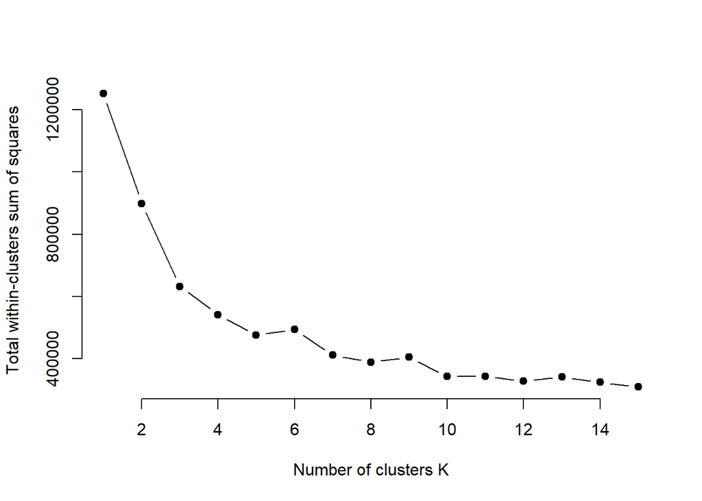

```r
plot(1:k.max, wss,
     type="b", pch = 19, frame = FALSE,
     xlab="Number of clusters K",
     ylab="Total within-clusters sum of squares")
```

### Additional Reading Resources

Here are the papers that are referenced in this markdown file regarding k-modes and k-prototype.

Huang, Zhexue (1997). Clustering Large Data Sets with Mixed Numeric and Categorical Variables. Available at: http://citeseerx.ist.psu.edu/viewdoc/summary?doi=10.1.1.94.9984. Accessed 16 April 2018.

Huang, Zhexue (1997b). A Fast Clustering Algorithm to Cluster Very Large Categorical Data Sets in Data Mining. Available at: http://citeseerx.ist.psu.edu/viewdoc/download?doi=10.1.1.134.83&rep=rep1&type=pdf. Accessed 16 April 2018.

Huang, Zhexue (1998). Extensions to the k-means Algorithm for Clustering Large Data Sets with Categorical Values. Available at: http://arbor.ee.ntu.edu.tw/~chyun/dmpaper/huanet98.pdf. Accessed 16 April 2018.